# python101-slides slides

## 1 My first program

```python
print("Hello world!")
```

```
Hello world!
```

## 2 Functions

Functions receive **arguments** and **return** whatever you want them to return.

```python
def sayhello(name):
    return "Hello, " + name
sayhello("John")
```

```
'Hello, John'
```

Use `raw_input` to receive input from the user.

```python
def whatsyourname():
    name = raw_input("What's your name? ")
    return "Hello, " + name
whatsyourname()
```

```
What's your name? Yair
```

```
'Hello, Yair'
```

**Exercise**: Write other functions

- "square" returns the square of the input argument
- "age" asks the year you were born and returns your age
- "bmi" asks your height (m) and weight (kg) and returns your Body Mass Index (BMI = weight / height$^2$)

It is important to distinguish between "=" and "==". Other operators used for comparison are ">", ">=", "<", "<=", and "!=" (not equal). Comparison operators return either "True" or "False".

```python
a = 4     # assignment
print(a)
a == 4    # equality operator
```

```
4
```

```
True
```

## 3 Arithmetic operators

Common operators used in arithmetic:  
$x+y$,  
$x-y$,  
$x*y$,  
$x\,/\,y$,  
$x**y$ (x to the power of y).

```python
10 % 3  # remainder operator
```

```
1
```

**Exercise:** Play with arithmetic operators and with the comparison operators to get a feel of how they work.

## 4 If-else clause

```python
b = 5
if b % 2 == 0:
    print(str(b) + " is even")
else:
    print(str(b) + " is odd")
```

```
5 is odd
```

Indentation (spaces to the left of commands) are important in python, but not necessarily in other languages. They keep together all the commands that belong to the same structure.

**Exercise:** write a function called `iseven` that returns either `True` or `False` depending if the argument passed is even or odd.

```python
def iseven(n):
    return n % 2 == 0
iseven(4)
```

```
True
```

**Exercise:** Write the following functions:

- `isodd` checks if the number is odd.
- `isnegative` checks if the number is negative
- `greater` receives 2 arguments, and returns the greatest one.

## 5 Range, lists, and slicing

This is how range works: `range(start, end, step)`.  
`len` gives you the length of the list.

```python
c = range(10)
print(c)
```

[output not shown]

```python
print(len(c))
```

```
10
```

```python
print(range(3,10,3))
```

```
[3, 6, 9]
```

**Exercise:** Create the following lists:

- `[3, 2, 1, 0, -1, -2, -3, -4]`
- `[12, 16, 20, 24, 28]`

We can **"slice"** a list, to get specific element(s). Here are some examples of "slicing".

```python
print(c[:])  # all elements
print(c[0])  # first element
print(c[-1])  # last element
print(c[0:4])  # first 4 elements
print(c[-3:-1])  # last 2 elements
print(c[5:])  # from element 5 to the end
print(c[:7])  # from first up to element 6
print(c[1:8:2]) # from 2nd element to 9th element, every other element
print(c[::-1])  # reverses the list
```

```
[0, 1, 2, 3, 4, 5, 6, 7, 8, 9]
0
9
[0, 1, 2, 3]
[7, 8]
[5, 6, 7, 8, 9]
[0, 1, 2, 3, 4, 5, 6]
[1, 3, 5, 7]
[9, 8, 7, 6, 5, 4, 3, 2, 1, 0]
```

## 6 For loop

A **for** loop scans a list and does intructions at every cycle. Play with it! This is one of the most important tools in programming!

```python
for value in c:
    print(value + 0.3)
```

```
0.3
1.3
2.3
3.3
4.3
5.3
6.3
7.3
8.3
9.3
```

**Exercises:** Do the following using a for loop:

- print even numbers from 0 to 20
- print even numbers from 13 to 35
- print the following output:

```python
[0]
[0, 1]
[0, 1, 2]
[0, 1, 2, 3]
[0, 1, 2, 3, 4]
```

## 7 if-else clauses

You can combine a for loop with if-else clauses.

```python
for value in c:
    if iseven(value):
        print(str(value) + " is even")
    else:
        print(str(value) + " is odd")
```

```
0 is even
1 is odd
2 is even
3 is odd
4 is even
5 is odd
6 is even
7 is odd
8 is even
9 is odd
```

You can stop a loop from completing using `break`.

```python
for i in range(20):
    print(i)
    if i > 7:
        print("That's it! Enough!")
        break  # this stops the loop
```

```
0
1
2
3
4
5
6
7
8
That's it! Enough!
```

Let's write a piece of code that sums all the integers 1, 2, 3, ... up to N.

```python
N = 50
num = range(1,N+1)
total = 0
for v in num:
    total = total + v
print("The sum of all numbers from 1 to " + str(N) + " is " + str(total))
```

```
The sum of all numbers from 1 to 50 is 1275
```

Now put this inside a function called `sumall` that received inputs n1, n2, and that returns the sum of all integers between n1 and n2.

```python
def sumall(n1,n2):
    total = 0
    for v in range(n1, n2 + 1):
        total = total + v
    return total
sumall(8,81)
```

```
3293
```

**Exercices:** Write the following function:

- `factorial(N)` returns... guess what?!

## 7 List manipulations

```python
k = []
for i in range(10):
    k.append(i**2)
print(k)
```

```
[0, 1, 4, 9, 16, 25, 36, 49, 64, 81]
```

```python
def fibonacci(n):
    f = [0, 1]
    for i in range(n):
        f.append(f[-1] + f[-2])
    return f
print(fibonacci(10))
print(len(fibonacci(10)))
```

```
[0, 1, 1, 2, 3, 5, 8, 13, 21, 34, 55, 89]
12
```

```python
cars = ["mazda", "toyota", "bmw"]
colors = ["blue", "red", "green", "black"]

for i in range(len(cars)):
    for j in range(len(colors)):
        print(colors[j] + " " + cars[i])

# this is the same, but simpler
# for car in cars:
#     for color in colors:
#         print(color + " " + car)
```

```
blue mazda
red mazda
green mazda
black mazda
blue toyota
red toyota
green toyota
black toyota
blue bmw
red bmw
green bmw
black bmw
```

## 8 Prime numbers!

```python
def isprime(n):
    i=2
    for i in range(2,n):
        if n % i == 0:
            break
    if i == n-1:
        return True
    else:
        return False
isprime(19)
```

```
True
```

```python
q = 500
prime = []
for w in range(2,q+1):
    if isprime(w):
        prime.append(w)
print(prime)
```

[output not shown]

```python
def prime_interval(p,q):
    prime = [2]
    for w in range(p,q+1):
        if isprime(w):
            prime.append(w)
    return(prime)
prime_interval(200,230)
```

```
[2, 211, 223, 227, 229]
```

## 9 Visualize stuff (plotting)

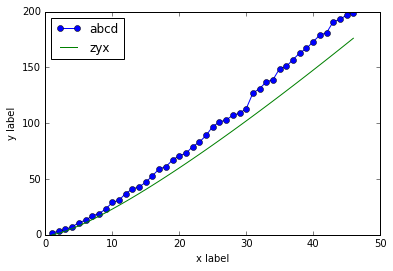

```python
%matplotlib inline
import matplotlib.pyplot as plt
import numpy as np
N = 200
p = prime_interval(2,N)
x = range(1,len(p)+1)
plt.plot(x,p, '-o', label="abcd")
plt.plot(x,x*np.log(x), label="zyx")
plt.xlabel("x label")
plt.ylabel("y label")
plt.legend(loc="upper left")
```